# Public Health with INLA - Day 1

Janet van Niekerk (janet.vanNiekerk@kaust.edu.sa/janet.vanNiekerk@up.ac.za)

October 2025

## Bayesian statistics

Conceptually we can illustrate Bayesian statistics with the following diagram.

[interactive chart not shown]

Figure 3.1: Schematic presentation of Bayesian statistics

## INLA

Integrated Nested Laplace Approximations (INLA) is an approximate method to do posterior inference. It does not use sampling, but explicitly calculates the posterior distributions of the elements in the latent field and the hyperparameters.

It is very very fast and accurate. and for huge samples (like climate models using global data), it is one of very few frameworks that can be used.

The only assumption needed is that the statistical model is a Latent Gaussian Model (LGM).

# Latent Gaussian models

This is a fancy name for a hierarchical Bayesian model of the following form:
$$\begin{eqnarray*}
&&Y\sim F(\mu,\pmb{\theta}_1) \text{any likelihood}\\
&&\mu = g(\eta)\text{, with } \eta = \pmb{X\beta}^\top +
\sum_{j=1}^{k}f^{j}(\pmb{u}_j|\pmb{\theta}_2)\\
&&\{\pmb{\eta},\pmb{B}, \pmb{f}\}\sim
\color{blue}{N(\pmb{0},\pmb{Q}^{-1})} \\
&&\pmb{\theta}=\{\pmb{\theta}_1,\pmb{\theta}_2\}\sim G(...)
\text{any prior for the hyperparameters}
\end{eqnarray*}$$

Most statistical models are actually LGM’s - spatial models, temporal models, spline models, GLM, GLZ, survival models, joint models etc.

## R-INLA

The INLA methodology has been implemented in an R package named *INLA* (hereafter known as R-INLA). The package is installed as follows

```r
install.packages("INLA",repos=c(getOption("repos"),INLA="https://inla.r-inla-download.org/R/testing"), dep=TRUE)
```

and the package can be updated periodically as follows

```r
inla.update(testing = TRUE)
```

The syntax for performing approximate Bayesian inference using INLA is to use the *inla* call with the formula, family, data and additional optional arguments as follows:

```r
result <- inla(formula, family, data)
```

The result is then an *inla object* for which we an use summary to retrieve some summary statistics of the posterior marginal distributions of the unknown parameters as

```r
summary(result)
```

The unknown model parameters in $\pmb M$ is grouped into *fixed* effects, *random* effects or *hyperparameters*. The default priors and possible likelihoods can be found with

```r
#Which likelihoods?
names(inla.models()$likelihood)
#What are the default priors?
inla.set.control.fixed.default()
#Details of the models
inla.doc("sn")
```

For each of these groups we can obtain the summary statistics or the marginal posterior density using

```r
result$summary.fixed
result$summary.random
result$summary.hyperpar
result$marginals.fixed
result$marginals.random
result$marginals.hyperpar
```

We can also obtain the inference for the linear predictors $\pmb\eta$ if we add the optional argument *control.predictor = list(compute = TRUE)* to the inla call as

```r
result <- inla(formula, family, data,
               control.predictor = list(compute = TRUE))
result$summary.linear.predictor
result$marginal.linear.predictor
```

Some vignettes:

```r
browseVignettes(package = "INLA")
```

## Example 1 - Binaryregression

Consider a dichotomous outcome (the outcome variable $y$ can be either $1$ or $0$). Suppose we have covariates $\pmb z$ that we want to regress on the outcome variable $y$. Since the support of the outcome variable is not the real line, we cannot assume a Gaussian distribution for the outcome variable like in general linear models, instead we need a generalized linear model formulated specifically for dichotomous outcomes. Two such models that are popular in practice are logistic regression models and probit models. The logistic regression model links the covariates to the outcome variable through a *logit* link function such that
$$\begin{equation}
P(Y=1) = \frac{\exp(\eta)}{1+\exp(\eta)}
\end{equation}$$
whereas the probit model links the covariates to the outcome variable through the *Gaussian cumulative distribution link function*, $\Phi(.)$ such that
$$\begin{equation}
P(Y=1) = \Phi(\eta).
\end{equation}$$
The default link function in INLA is the logit link as can be seen in

```r
inla.doc("binomial")
```

We use the *melanoma* dataset in the *boot* library. The dataset contains information on the survival of patients with malignant melanoma after a tumor removal surgery.

```r
data(melanoma, package = "boot")
summary(melanoma)
```

```
##       time          status          sex              age             year
##  Min.   :  10   Min.   :1.00   Min.   :0.0000   Min.   : 4.00   Min.   :1962
##  1st Qu.:1525   1st Qu.:1.00   1st Qu.:0.0000   1st Qu.:42.00   1st Qu.:1968
##  Median :2005   Median :2.00   Median :0.0000   Median :54.00   Median :1970
##  Mean   :2153   Mean   :1.79   Mean   :0.3854   Mean   :52.46   Mean   :1970
##  3rd Qu.:3042   3rd Qu.:2.00   3rd Qu.:1.0000   3rd Qu.:65.00   3rd Qu.:1972
##  Max.   :5565   Max.   :3.00   Max.   :1.0000   Max.   :95.00   Max.   :1977
##    thickness         ulcer
##  Min.   : 0.10   Min.   :0.000
##  1st Qu.: 0.97   1st Qu.:0.000
##  Median : 1.94   Median :0.000
##  Mean   : 2.92   Mean   :0.439
##  3rd Qu.: 3.56   3rd Qu.:1.000
##  Max.   :17.42   Max.   :1.000
```

The *status* variable is the response in this case where $1$ denotes that the patient died of melanoma and $0$ indicates that the patient did not die of melanoma.

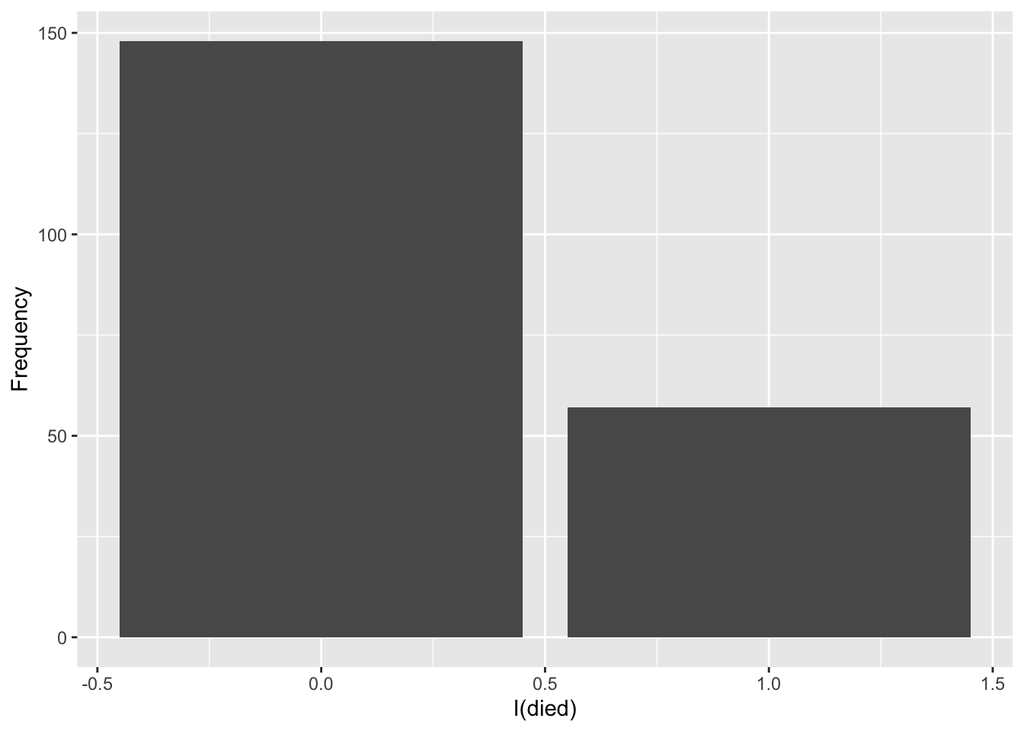

```r
#Code into binary events (1 - died from melanoma,
#                   0 - did not die from melanoma)
melanoma$status[melanoma$status==2] = 0
melanoma$status[melanoma$status==3] = 0
prop_died = sum(melanoma$status[melanoma$status==1])/nrow(melanoma)

ggplot(melanoma, aes(x = status)) + geom_bar() +
  labs(x = "I(died)", y = "Frequency")
```

We see that 27.804878 $\%$ died from malignant melanoma during the study period. The covariates we consider are *age, sex, year*(year of surgery), *thickness, ulcer*(if the removed tumor were ulcerated, believed to be an important prognostic factor). For interpretibility, we scale the continuous covariates to have a zero mean and unit variance, and we scale *year* to be the number of years since the first surgery,.

```r
#Baseline characteristics
mean(melanoma$age)
```

```
## [1] 52.46341
```

```r
mean(melanoma$thickness)
```

```
## [1] 2.919854
```

```r
min(melanoma$year)
```

```
## [1] 1962
```

```r
#Scale the continuous covariates for the fixed effects
melanoma$age = scale(melanoma$age)
melanoma$thickness = scale(melanoma$thickness)
melanoma$year = melanoma$year - min(melanoma$year)
```

Baseline patient - Patient with average age, with a tumor thickness equal to the average thickness and who had the removal surgery in the earliest year, have sex = 0 and ulcer = 0.

Now we are ready to fit the logistic regression model
$$\begin{equation}
P(status=1) = \frac{\exp(\eta)}{1+\exp(\eta)}
\end{equation}$$
where
$$\begin{equation}
\eta = \beta_0 + \beta_{Age}age + \beta_{Sex=1}I(Sex=1) +
\beta_{Year}year + \beta_{Thickness}thickness +
\beta_{Ulcer=1}I(Ulcer=1)
\end{equation}$$

```r
#INLA model
model3.1 <- inla(formula = status ~ 1 + age + sex + year + thickness + ulcer,
                 family = "binomial",
                 data = melanoma)
```

We can view a summary of the results from the model, available in the INLA object *model3.1*.

```r
summary(model3.1)
```

```
## Time used:
##     Pre = 5.13, Running = 0.631, Post = 0.0536, Total = 5.82
## Fixed effects:
##               mean    sd 0.025quant 0.5quant 0.975quant   mode kld
## (Intercept) -0.381 0.583     -1.523   -0.381      0.761 -0.381   0
## age          0.209 0.185     -0.153    0.209      0.572  0.209   0
## sex          0.476 0.354     -0.218    0.476      1.171  0.476   0
## year        -0.213 0.073     -0.356   -0.213     -0.070 -0.213   0
## thickness    0.269 0.180     -0.084    0.269      0.623  0.269   0
## ulcer        1.471 0.382      0.723    1.471      2.219  1.471   0
##
## Marginal log-Likelihood:  -127.28
##  is computed
## Posterior summaries for the linear predictor and the fitted values are computed
## (Posterior marginals needs also 'control.compute=list(return.marginals.predictor=TRUE)')
```

We see from the $95/%$ credible intervals that only *year* and *ulcer* are statistically significant covariates in explaining the variation in the *status* variable. Since $\beta_{Year}\in$ (-0.3556603; -0.0704273), we can infer that earlier years of surgery increases the odds of dying from malignant melanoma, compared to later years. Also, an ulcerated tumor increases the odds of dying from malignant melanoma, since $\beta_{Ulcer=1}\in$ (0.7228903; 2.2187637).

We can also extract the posterior distributions of the fixed effects from the INLA object *model3.1*

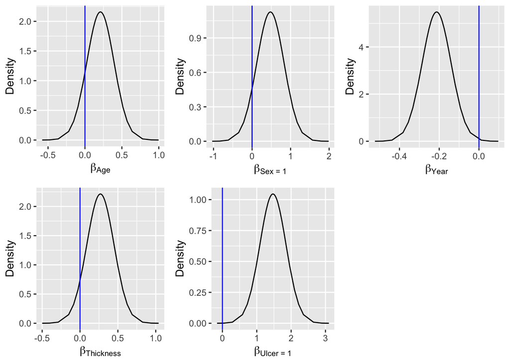

```r
#posterior marginals of the model components
pAge <- ggplot(data.frame(model3.1$marginals.fixed$age), aes(x=x, y=y)) + geom_line() +
  labs(x = expression(beta["Age"]), y = "Density") +
  geom_vline(xintercept = 0, col = "blue")

pSex <- ggplot(data.frame(model3.1$marginals.fixed$sex ), aes(x=x, y=y)) + geom_line() +
  labs(x = expression(beta["Sex = 1"]), y = "Density") +
  geom_vline(xintercept = 0, col = "blue")

pYear <- ggplot(data.frame(model3.1$marginals.fixed$year ), aes(x=x, y=y)) + geom_line() +
  labs(x = expression(beta["Year"]), y = "Density") +
  geom_vline(xintercept = 0, col = "blue")

pThickness <- ggplot(data.frame(model3.1$marginals.fixed$thickness ), aes(x=x, y=y)) + geom_line() +
  labs(x = expression(beta["Thickness"]), y = "Density") +
  geom_vline(xintercept = 0, col = "blue")

pUlcer <- ggplot(data.frame(model3.1$marginals.fixed$ulcer ), aes(x=x, y=y)) + geom_line() +
  labs(x = expression(beta["Ulcer = 1"]), y = "Density") +
  geom_vline(xintercept = 0, col = "blue")

ggarrange(pAge, pSex, pYear, pThickness, pUlcer,
          nrow = 2, ncol = 3)
```

We can also calculate posterior inference for the odds ratio’s:

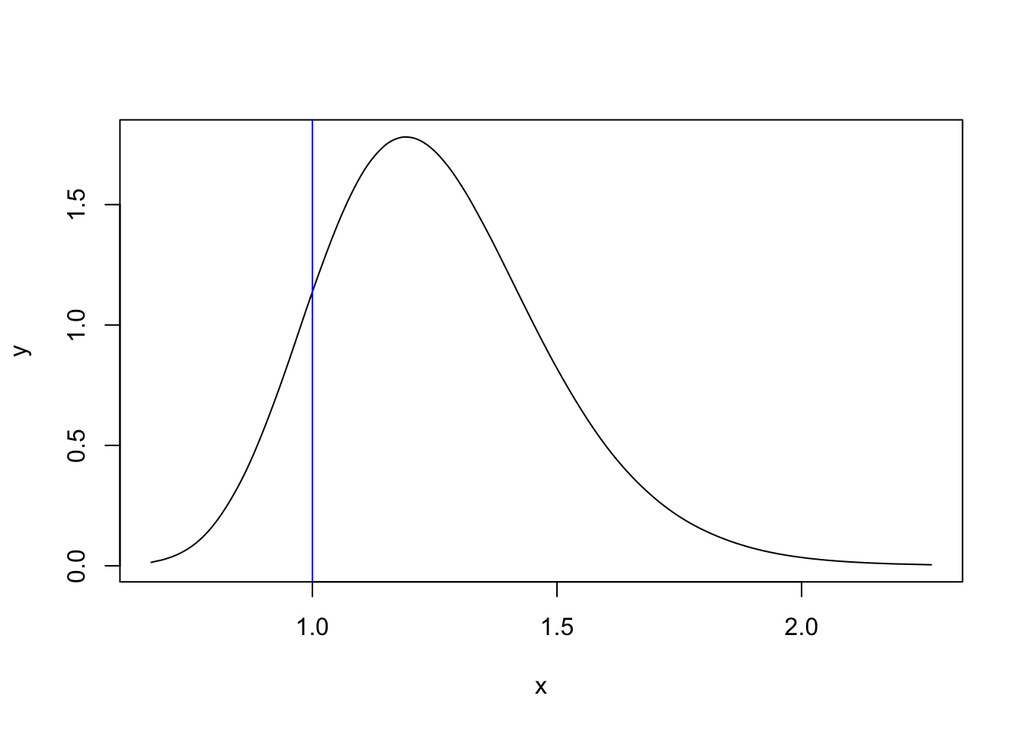

```r
#OR <- exp(beta)
OR_age <- inla.tmarginal(function(x) exp(x),
                         model3.1$marginals.fixed$age)
plot(OR_age, type = "l")
abline(v = 1, col = "blue")
```

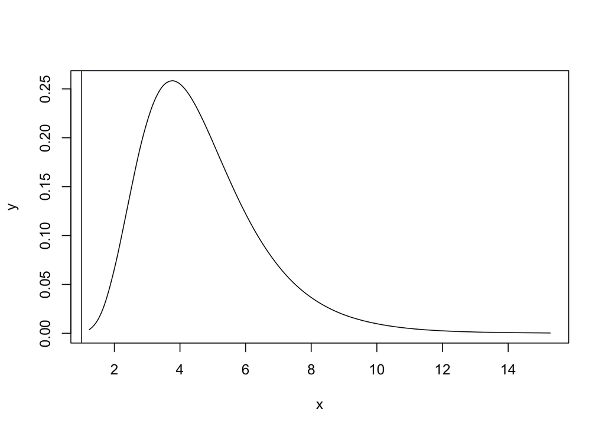

```r
OR_ulcer <- inla.tmarginal(function(x) exp(x),
                         model3.1$marginals.fixed$ulcer)
plot(OR_ulcer, type = "l")
abline(v = 1, col = "blue")
```

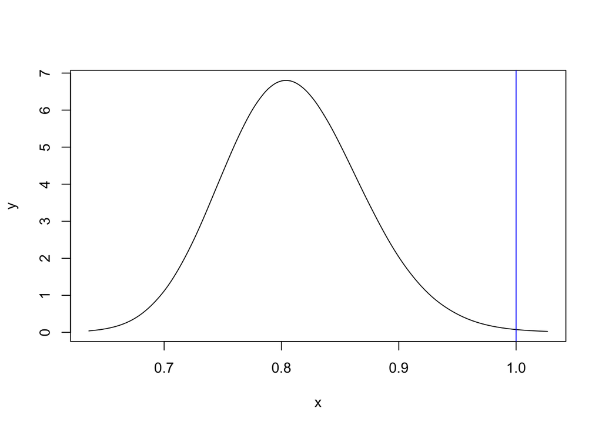

```r
OR_year <- inla.tmarginal(function(x) exp(x),
                         model3.1$marginals.fixed$year)
plot(OR_year, type = "l")
abline(v = 1, col = "blue")
```

## Example 2 - GLZ

In this example we use the North Carolina Sudden Infant Death Syndrome dataset.

```r
data(nc.sids)
head(nc.sids)
```

```
##             CNTY.ID BIR74 SID74 NWBIR74 BIR79 SID79 NWBIR79 east north      x
## Ashe           1825  1091     1      10  1364     0      19  164   176 -81.67
## Alleghany      1827   487     0      10   542     3      12  183   182 -50.06
## Surry          1828  3188     5     208  3616     6     260  204   174 -16.14
## Currituck      1831   508     1     123   830     2     145  461   182 406.01
## Northampton    1832  1421     9    1066  1606     3    1197  385   176 281.10
## Hertford       1833  1452     7     954  1838     5    1237  411   176 323.77
##                   y       lon      lat L.id M.id
## Ashe        4052.29 -81.48594 36.43940    1    2
## Alleghany   4059.70 -81.14061 36.52443    1    2
## Surry       4043.76 -80.75312 36.40033    1    2
## Currituck   4035.10 -76.04892 36.45655    1    4
## Northampton 4029.75 -77.44057 36.38799    1    4
## Hertford    4028.10 -76.96474 36.38189    1    4
```

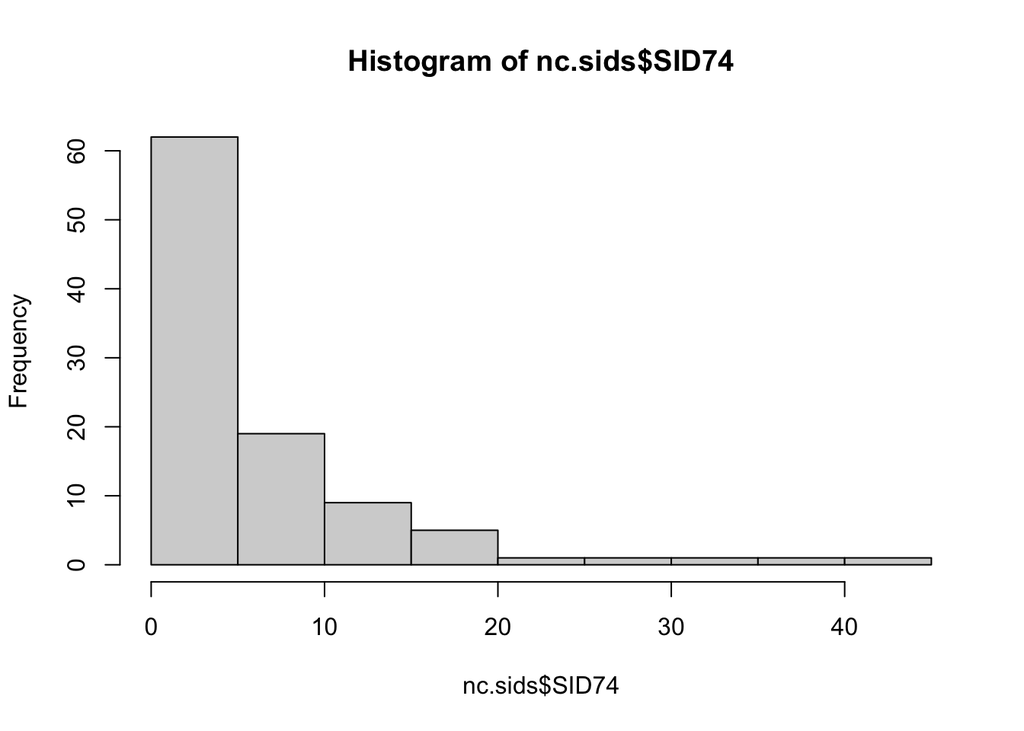

```r
hist(nc.sids$SID74)
```

```r
summary(nc.sids)
```

```
##     CNTY.ID         BIR74           SID74          NWBIR74
##  Min.   :1825   Min.   :  248   Min.   : 0.00   Min.   :   1.0
##  1st Qu.:1902   1st Qu.: 1077   1st Qu.: 2.00   1st Qu.: 190.0
##  Median :1982   Median : 2180   Median : 4.00   Median : 697.5
##  Mean   :1986   Mean   : 3300   Mean   : 6.67   Mean   :1051.0
##  3rd Qu.:2067   3rd Qu.: 3936   3rd Qu.: 8.25   3rd Qu.:1168.5
##  Max.   :2241   Max.   :21588   Max.   :44.00   Max.   :8027.0
##      BIR79           SID79          NWBIR79             east
##  Min.   :  319   Min.   : 0.00   Min.   :    3.0   Min.   : 19.0
##  1st Qu.: 1336   1st Qu.: 2.00   1st Qu.:  250.5   1st Qu.:178.8
##  Median : 2636   Median : 5.00   Median :  874.5   Median :285.0
##  Mean   : 4224   Mean   : 8.36   Mean   : 1352.8   Mean   :271.3
##  3rd Qu.: 4889   3rd Qu.:10.25   3rd Qu.: 1406.8   3rd Qu.:361.2
##  Max.   :30757   Max.   :57.00   Max.   :11631.0   Max.   :482.0
##      north             x                 y             lon
##  Min.   :  6.0   Min.   :-328.04   Min.   :3757   Min.   :-84.08
##  1st Qu.: 97.0   1st Qu.: -60.55   1st Qu.:3920   1st Qu.:-81.20
##  Median :125.5   Median : 114.38   Median :3963   Median :-79.26
##  Mean   :122.1   Mean   :  91.46   Mean   :3953   Mean   :-79.51
##  3rd Qu.:151.5   3rd Qu.: 240.03   3rd Qu.:4000   3rd Qu.:-77.87
##  Max.   :182.0   Max.   : 439.65   Max.   :4060   Max.   :-75.67
##       lat             L.id           M.id
##  Min.   :33.92   Min.   :1.00   Min.   :1.00
##  1st Qu.:35.26   1st Qu.:1.00   1st Qu.:2.00
##  Median :35.68   Median :2.00   Median :3.00
##  Mean   :35.62   Mean   :2.12   Mean   :2.67
##  3rd Qu.:36.05   3rd Qu.:3.00   3rd Qu.:3.25
##  Max.   :36.52   Max.   :4.00   Max.   :4.00
```

We see that the number of deaths is a count variable and therefore propose a Poisson regression model, i.e.
$$y\sim Poi(E\theta)$$
with
$$\theta = \exp(\eta)$$
and $E$ is the expected count. In this way, $\theta$ indicates the risk. We need to calculate the expected count for each observation,

```r
p_hat <- sum(nc.sids$SID74) / sum(nc.sids$BIR74)
nc.sids$E74 <- p_hat * nc.sids$BIR74
```

We use the NWBIR as a covariate to investigate if it has any influence on the risk of SIDS. We consider the proportion instead of the count,

```r
nc.sids$nwp_hat74 <- nc.sids$NWBIR74 / nc.sids$BIR74
```

Now we can fit the Poisson regression model,

```r
result1_sids <- inla(formula = SID74 ~ 1 + nwp_hat74,
                     family = "poisson",
                     E = E74,
                     data = nc.sids,
                     control.predictor = list(compute = TRUE))
```

The posterior summaries of this model is

```r
summary(result1_sids)
```

```
## Time used:
##     Pre = 5.04, Running = 0.52, Post = 0.032, Total = 5.6
## Fixed effects:
##               mean    sd 0.025quant 0.5quant 0.975quant   mode kld
## (Intercept) -0.647 0.090     -0.824   -0.647     -0.471 -0.647   0
## nwp_hat74    1.867 0.217      1.441    1.867      2.293  1.867   0
##
## Marginal log-Likelihood:  -226.13
##  is computed
## Posterior summaries for the linear predictor and the fitted values are computed
## (Posterior marginals needs also 'control.compute=list(return.marginals.predictor=TRUE)')
```

We can also visually investigate how the fitted values from the model fits onto the observed data,

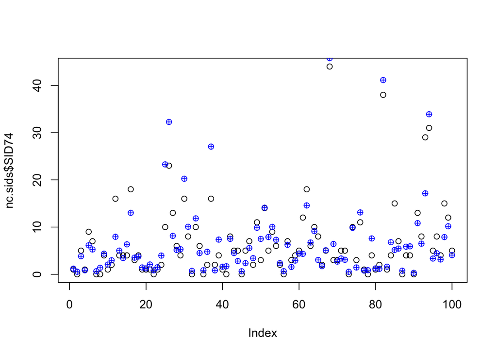

```r
plot(nc.sids$SID74)
points(nc.sids$E74*result1_sids$summary.fitted.values$mean , col = "blue", pch = 10)
```

When we look at the data we see that the observations are form different counties and from a public health viewpoint this can provide interesting insight. We add a random intercept for each county to the Poisson regression model, so that we know have a mixed effects model.

```r
result2_sids <- inla(formula = SID74 ~ 1 + nwp_hat74 +
                       f(CNTY.ID, model = "iid", hyper = list(theta = list(param = c(2,2), prior = "loggamma"))),
                     family = "poisson",
                     E = E74,
                     data = nc.sids,
                     control.predictor = list(compute = TRUE))
summary(result2_sids)
```

[output not shown]

```r
#What is the default prior for the iid model?
#inla.models()$latent$iid$hyper$theta
```

The extra hyperparameter, the standard deviation of the random intercept has the following posterior,

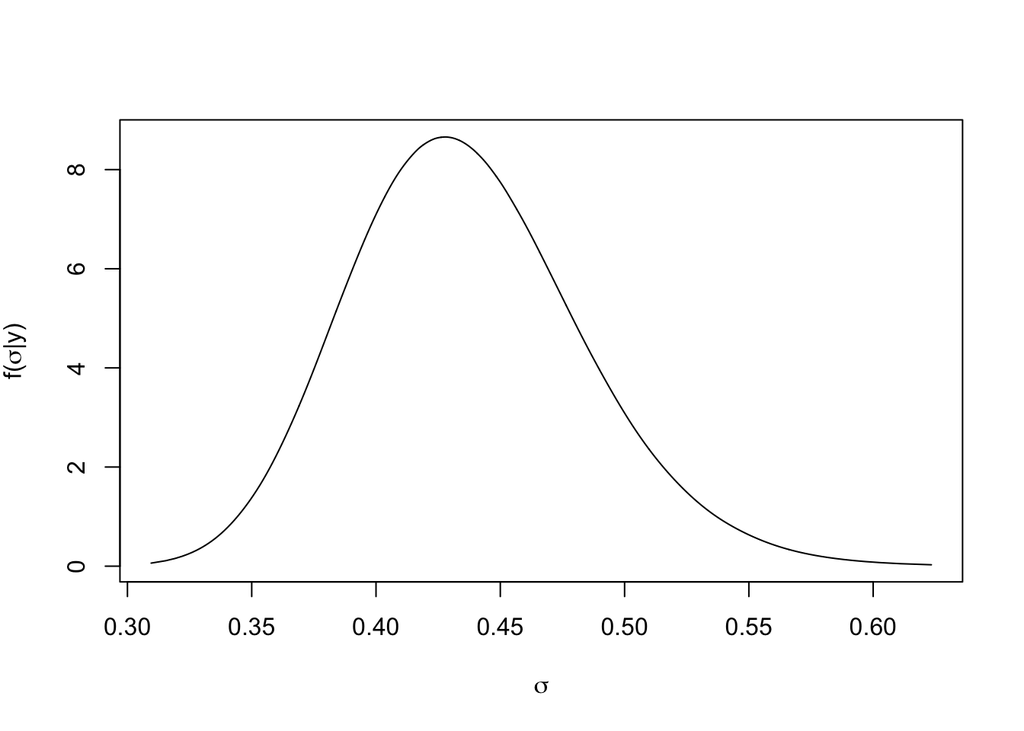

```r
res2_sd_rint <- inla.tmarginal(function(x) sqrt(1/x), result2_sids$marginals.hyperpar$`Precision for CNTY.ID`)
plot(res2_sd_rint, type = "l", xlab = expression(sigma), ylab = expression(paste("f(", sigma ,"|y)")))
```

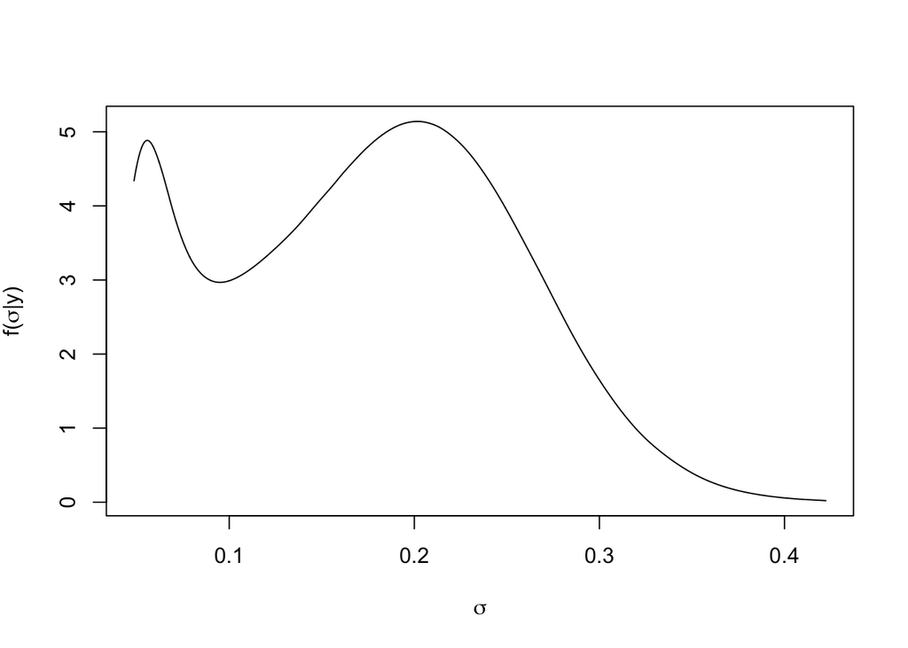

```r
result2d_sids <- inla(formula = SID74 ~ 1 + nwp_hat74 +
                       f(CNTY.ID, model = "iid"),
                     family = "poisson",
                     E = E74,
                     data = nc.sids,
                     control.predictor = list(compute = TRUE))
res2d_sd_rint <- inla.tmarginal(function(x) sqrt(1/x), result2d_sids$marginals.hyperpar$`Precision for CNTY.ID`)
plot(res2d_sd_rint, type = "l", xlab = expression(sigma), ylab = expression(paste("f(", sigma ,"|y)")))
```

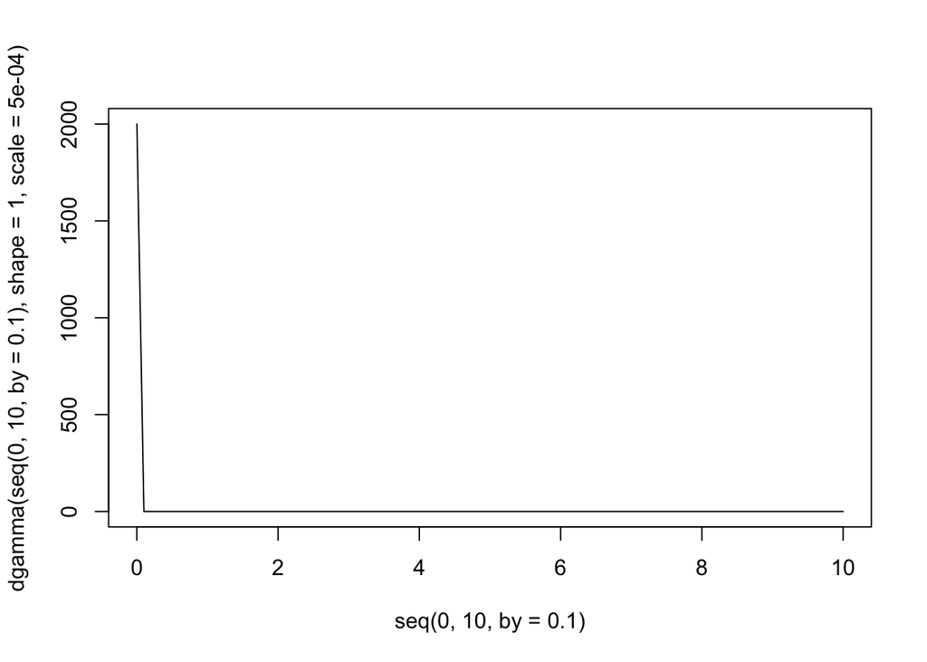

```r
#Default prior for tau in the iid model
plot(seq(0, 10, by=0.1),
     dgamma(seq(0, 10, by=0.1),
            shape = 1, scale = 0.0005),
     type = "l")
```

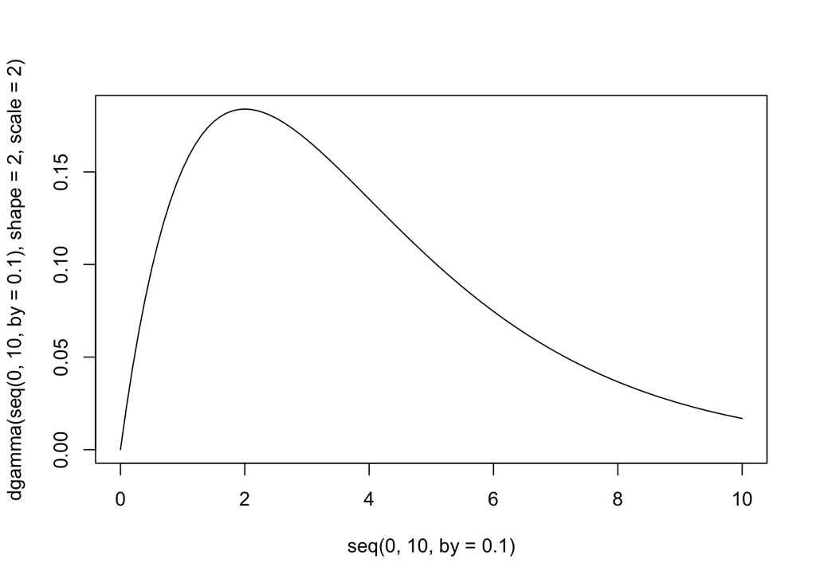

```r
#Very strict

plot(seq(0, 10, by=0.1),
     dgamma(seq(0, 10, by=0.1),
            shape = 2, scale = 2),
     type = "l")
```

```r
#Better choice - weaker
```

We can also visually investigate how the fitted values from the model fits onto the observed data,

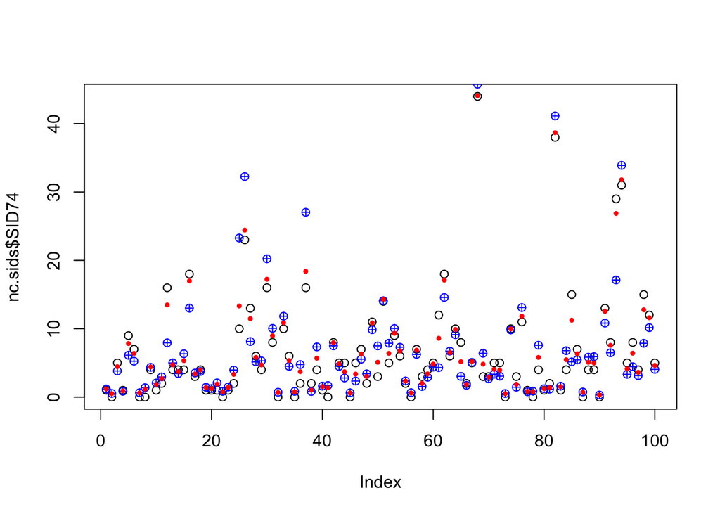

```r
plot(nc.sids$SID74)
points(nc.sids$E74*result1_sids$summary.fitted.values$mean , col = "blue", pch = 10)
points(nc.sids$E74*result2_sids$summary.fitted.values$mean , col = "red", pch = 19, cex = 0.5)
```

Adding a random intercept adds an independent effect, although the counties are probably not independent in terms of socio-economic diversity. So we should rather include a structured random effect such that some “intercepts” are correlated with each other, conveying the dependence in space (Day 3 material) When we compare the fit between models we can look at the marginal log-likelihoods, DIC or WAIC.

```r
result1_sids <- inla(formula = SID74 ~ 1 + nwp_hat74,
                     family = "poisson",
                     E = E74,
                     data = nc.sids,
control.predictor = list(compute = TRUE),
control.compute   = list(dic = TRUE, waic = TRUE))

result2_sids <- inla(formula = SID74 ~ 1 + nwp_hat74 +
                       f(CNTY.ID, model = "iid", hyper = list(theta = list(param = c(2,2), prior = "loggamma"))),
                     family = "poisson",
                     E = E74,
                     data = nc.sids,
                     control.predictor = list(compute = TRUE),
                     control.compute = list(dic = T, waic = T))

print(matrix(rbind(cbind(result1_sids$mlik[1],
                         result1_sids$dic[1],
                         result1_sids$waic[1]),
            cbind(result2_sids$mlik[1],
                         result2_sids$dic[1],
                         result2_sids$waic[1])),
            nrow = 2, ncol = 3,
            dimnames = list(c("Model 1", "Model 2"),
                            c("Marginal log-likelihood", "DIC", "WAIC")
                            )))
```

```
##         Marginal log-likelihood DIC      WAIC
## Model 1 -226.1261               441.6218 442.7613
## Model 2 -231.3668               434.6854 422.0957
```

We can also do cross-validation as a means of measuring prediction performance.